# Working with Text

Introduction to R For Biologists and Bioinformatics

Author

Affiliation

Dr Stevie Pederson

Black Ochre Data Labs  
Telethon Kids Institute

Published

September 19, 2023

# Working With Text

## Section Setup

- Clear your `R` Environment
- Create a new R script `TextManipulation.R`
- Add `library(tidyverse)` to the top of the script and execute

## Working with Text

- Text manipulation is an essential part of most analyses
  - Tidying axis labels
  - Correcting errors
  - Extracting shorter sample ids from full names
- Regular Expressions form a key part of this
  - Pattern matching technique used in `bash`, `python` etc
  - `R` syntax is slightly different but mostly compatible

. . .

- We need to understand a little about vectors first

## Vectors

> **Vectors** are zero or more values of the same type

. . .

- We saw them earlier `x <- 1:5`
  - This was an vector of length 5
  - Values were all integers

```r
x <- 1:5
typeof(x)
```

```
[1] "integer"
```

. . .

- All columns of `pigs` were also vectors
  - `len` was `numeric` (or `double`)
  - `dose` and `supp` were `character` vectors

## Vectors

- In `R` we form vectors using the function `c()`
  - Used to combine elements into a single vector
  - One of the most heavily used functions in `R`

. . .

- The shorthand `x <- 1:5` could also be written as

```r
x <- c(1L, 2L, 3L, 4L, 5L)
typeof(x)
```

```
[1] "integer"
```

- To ensure these were integers we placed an `L` after each

## Vectors

- By default `R` usually assumes numbers are doubles
  - Doubles are numbers with something after decimal point

```r
x <- c(1, 2, 3, 4, 5)
typeof(x)
```

```
[1] "double"
```

. . .

- Can coerce doubles to integers using `as.integer()`
  - Just drops anything after the decimal point

```r
x2 <- as.integer(x)
typeof(x2)
```

```
[1] "integer"
```

- Won’t explore in any more detail today

Difference between integers and numeric not super relevant for today

## Vectors

> **Vectors** are zero or more values of the same type

. . .

- `R` has 6 types of atomic vectors
  - All relevant internally for how `R` allocates memory
  - Only 4 are relevant to us in practice

. . .

1. `logical`: Can only be `TRUE` or `FALSE`

. . .

2. `integer`: Whole number values $\implies$ counts, positions etc.

. . .

3. `numeric`: Numbers with decimal points (aka `double`)

. . .

4. `character`: Any text
- Doubles need to store the values after the decimal point to have much larger memory requirements.
- The other atomic types are complex (sqrt(-1)) and `raw`
- Raw vectors hold raw bytes

## Character Vectors

- We can use `c()` to form a character vector
- All values must be quoted $\implies$ unquoted text represents an `R` object

```r
pets <- c("My dog", "Your cat", "No-one's rat")
pets
```

```
[1] "My dog"       "Your cat"     "No-one's rat"
```

```r
length(pets)
```

```
[1] 3
```

. . .

- We can extract values using square brackets `[]`

```r
pets[3]
```

```
[1] "No-one's rat"
```

## Named Vectors

- Vectors can also have names
  - Names are character vectors
- The exchange rate at the time the EURO commenced is an object in `R`
  - Names indicate the original currency

```r
euro
```

```
        ATS         BEF         DEM         ESP         FIM         FRF
  13.760300   40.339900    1.955830  166.386000    5.945730    6.559570
        IEP         ITL         LUF         NLG         PTE
   0.787564 1936.270000   40.339900    2.203710  200.482000
```

```r
names(euro)
```

```
 [1] "ATS" "BEF" "DEM" "ESP" "FIM" "FRF" "IEP" "ITL" "LUF" "NLG" "PTE"
```

## Named Vectors

- We can use these to subset, as well as by position
  - Note we have created a character vector to call-by-name  
    $\implies$ `c("ATS", "BEF", "DEM")`
  - No need to save it $\implies$ we created it ‘on-the-fly’

```r
euro[1:3]
```

```
     ATS      BEF      DEM
13.76030 40.33990  1.95583
```

```r
euro[c("ATS", "BEF", "DEM")]
```

```
     ATS      BEF      DEM
13.76030 40.33990  1.95583
```

. . .

- `pets` has no names so we have to use position only
- Using names makes your code *much easier* to read back later

# Text Manipulation Using `stringr`

## Text Manipulation

- `stringr` is always loaded with the `tidyverse`
- Contains nearly all functions you can imagine for text manipulation

. . .

- Count the characters

```r
str_length(pets)
```

```
[1]  6  8 12
```

. . .

- Trim to a set length

```r
str_trunc(pets, width = 6)
```

```
[1] "My dog" "You..." "No-..."
```

## Text Manipulation

- Change the case of strings

```r
str_to_upper(pets)
```

```
[1] "MY DOG"       "YOUR CAT"     "NO-ONE'S RAT"
```

```r
str_to_lower(pets)
```

```
[1] "my dog"       "your cat"     "no-one's rat"
```

```r
str_to_title(pets)
```

```
[1] "My Dog"       "Your Cat"     "No-One's Rat"
```

## Text Manipulation

- Sort vectors

```r
str_sort(pets)
```

```
[1] "My dog"       "No-one's rat" "Your cat"
```

. . .

- Can even be intelligent when numbers are included

```r
street_nums <- c("1A", "2", "11A", "9C")
str_sort(street_nums)
```

```
[1] "11A" "1A"  "2"   "9C"
```

```r
str_sort(street_nums, numeric = TRUE)
```

```
[1] "1A"  "2"   "9C"  "11A"
```

## Pattern Matching

```r
pets
```

```
[1] "My dog"       "Your cat"     "No-one's rat"
```

. . .

- We can search for single letters $\implies$ case-sensitive

```r
str_detect(pets, "y")
```

```
[1]  TRUE FALSE FALSE
```

. . .

- Or patterns

```r
str_detect(pets, "dog")
```

```
[1]  TRUE FALSE FALSE
```

## Extracting Text

- We can extract patterns from within each value

```r
str_extract(pets, "dog")
```

```
[1] "dog" NA    NA
```

. . .

- We can use the `|` to represent `OR`

```r
str_extract(pets, "dog|cat")
```

```
[1] "dog" "cat" NA
```

. . .

- Note that `NA` is returned where no pattern is found
  - i.e. the pattern is *missing* from that string
  - `NA` is Not Available / Missing

## Extracting Text

- We can specify a range of values
  - `"[A-Z]"` restricts the pattern to any *uppercase* letters

```r
str_extract(pets, "[A-Z]")
```

```
[1] "M" "Y" "N"
```

. . .

- Changing to lower-case using `"[a-z]"`
  - If multiple matches occur, *only the first match is returned*

```r
str_extract(pets, "[a-z]")
```

```
[1] "y" "o" "o"
```

## Extracting Text

- Patterns can be extended by adding a `+` symbol  
  $\implies$ Match one or more values
  - Will return the first match of *one or more lowercase letters*

```r
str_extract(pets, "[a-z]+")
```

```
[1] "y"   "our" "o"
```

. . .

- `[A-Za-z]` can be combined as `[:alpha:]`

```r
str_extract(pets, "[:alpha:]+")
```

```
[1] "My"   "Your" "No"
```

. . .

- What happened at each non-letter? *The match stopped*

## Removing Text

- We can remove patterns using `str_remove()`

```r
str_remove(pets, "o")
```

```
[1] "My dg"       "Yur cat"     "N-one's rat"
```

. . .

- This only removed the first match
  - `str_remove_all()` removes all matches

```r
str_remove_all(pets, "o")
```

```
[1] "My dg"      "Yur cat"    "N-ne's rat"
```

```r
str_remove_all(pets, "[A-Z]")
```

```
[1] "y dog"       "our cat"     "o-one's rat"
```

## Wildcards

- Regular Expressions use `"."` as a wildcard  
  $\implies$ `*` extends a match *zero* or more times (similar to `+`)

. . .

- The pattern `" ."` matches a space followed by anything

```r
str_remove_all(pets, " ")
```

```
[1] "Mydog"       "Yourcat"     "No-one'srat"
```

```r
str_remove_all(pets, " .")
```

```
[1] "Myog"       "Yourat"     "No-one'sat"
```

. . .

- A very common pattern is `".+"`
  - Means *match anything any number of times*

. . .

```r
str_remove_all(pets, " .+")
```

```
[1] "My"       "Your"     "No-one's"
```

. . .

- Often multiple ways to obtain your target

## Replacing Patterns

- `str_replace_all()` is the most powerful of the core functions
- Has arguments `string`, `pattern` and `replacement`
  - The pattern `"a"` will be replaced by `"o"`

```r
str_replace_all(pets, pattern = "a", replacement = "o")
```

```
[1] "My dog"       "Your cot"     "No-one's rot"
```

. . .

- Turn all lowercase letters into `a`

```r
str_replace_all(pets, "[a-z]", "a")
```

```
[1] "Ma aaa"       "Yaaa aaa"     "Na-aaa'a aaa"
```

## Replacing Patterns

- We can capture patterns and return however we wish
  - Patterns to capture are placed within a `"()"`
  - Captures are returned in order using `\\1` or `\\2` etc

. . .

- The follow pattern captures the entire text string `"(.+)"`
  - Match anything, any number of times
  - Then return with exclamations added

```r
str_replace_all(pets, "(.+)", "\\1!!!")
```

```
[1] "My dog!!!"       "Your cat!!!"     "No-one's rat!!!"
```

## Replacing Patterns

- We can also capture multiple patterns
  - Can you understand the following?

```r
str_replace_all(pets, "([A-Z]).+ (.+)", "\\2 \\1")
```

```
[1] "dog M" "cat Y" "rat N"
```

1. We captured an uppercase letter: `([A-Z])`
2. We matched anything up to a space: `.+`
   - But we didn’t capture it $\implies$ was outside the `()`
3. We captured everything after the space: `(.+)`
4. We returned the two captures in reverse order with a space between

## Other Useful Functions

- `paste()` is a key `base` function
  - Combines text from two vectors
  - `R` automatically recycles values when vector lengths don’t match

```r
paste(c("A", "B", "C"), 1:3)
```

```
[1] "A 1" "B 2" "C 3"
```

```r
paste(pets, "is great")
```

```
[1] "My dog is great"       "Your cat is great"     "No-one's rat is great"
```

## Other Useful Functions

- `paste()` uses `sep = " "` as the default separator
  - Can be any characters at all

```r
paste(pets, "Hmm...", sep = "? ")
```

```
[1] "My dog? Hmm..."       "Your cat? Hmm..."     "No-one's rat? Hmm..."
```

. . .

- `paste0()` is a shortcut for `paste(sep = "")`

```r
paste0(pets, "!!!")
```

```
[1] "My dog!!!"       "Your cat!!!"     "No-one's rat!!!"
```

## Working With Strings

- Is an incredibly common and important part of working with R
- Extract sample IDs from file names
- Pull key information from file names
- Remove prefixes/suffixes
- Correct data entry errors in your spreadsheet
- Format for pretty plotting

# Factors

## Factors

- Categorical variables are called `factors`
- `forcats` is the `tidyverse` package
  - Genius name…
- `base` functions are still very commonly used and simple
  - `as.factor()` and `factor()`

. . .

- Character vectors are always quoted when printed
- Factors are never shown quoted

**Very easy to mix characters and factors up**

## Factors

```r
pigs <- read_csv("data/pigs.csv")
dose <- pigs$dose
dose
```

```
 [1] "Low"  "Low"  "Low"  "Low"  "Low"  "Low"  "Low"  "Low"  "Low"  "Low"
[11] "Med"  "Med"  "Med"  "Med"  "Med"  "Med"  "Med"  "Med"  "Med"  "Med"
[21] "High" "High" "High" "High" "High" "High" "High" "High" "High" "High"
[31] "Low"  "Low"  "Low"  "Low"  "Low"  "Low"  "Low"  "Low"  "Low"  "Low"
[41] "Med"  "Med"  "Med"  "Med"  "Med"  "Med"  "Med"  "Med"  "Med"  "Med"
[51] "High" "High" "High" "High" "High" "High" "High" "High" "High" "High"
```

- Notice that we have many repeated values
  - Very common for categorical variables
- `as.factor()` from `base` creates factors in alphanumeric order
  - Prints the category levels at the bottom

```r
dose_fct <- as.factor(dose)
dose_fct
```

```
 [1] Low  Low  Low  Low  Low  Low  Low  Low  Low  Low  Med  Med  Med  Med  Med
[16] Med  Med  Med  Med  Med  High High High High High High High High High High
[31] Low  Low  Low  Low  Low  Low  Low  Low  Low  Low  Med  Med  Med  Med  Med
[46] Med  Med  Med  Med  Med  High High High High High High High High High High
Levels: High Low Med
```

- This is how our first boxplots were produced

## Factors

- We can manually set the levels using `factor()`
  - Levels are passed *as a character vector*
  - Enables us to manually set the order

```r
dose_fct <- factor(dose, levels = c("Low", "Med", "High"))
dose_fct
```

```
 [1] Low  Low  Low  Low  Low  Low  Low  Low  Low  Low  Med  Med  Med  Med  Med
[16] Med  Med  Med  Med  Med  High High High High High High High High High High
[31] Low  Low  Low  Low  Low  Low  Low  Low  Low  Low  Med  Med  Med  Med  Med
[46] Med  Med  Med  Med  Med  High High High High High High High High High High
Levels: Low Med High
```

## Forcats

- `forcats` offers some new approaches
  - `fct` creates factors in order (as does `fct_inorder()`)

```r
fct(dose)
```

```
 [1] Low  Low  Low  Low  Low  Low  Low  Low  Low  Low  Med  Med  Med  Med  Med
[16] Med  Med  Med  Med  Med  High High High High High High High High High High
[31] Low  Low  Low  Low  Low  Low  Low  Low  Low  Low  Med  Med  Med  Med  Med
[46] Med  Med  Med  Med  Med  High High High High High High High High High High
Levels: Low Med High
```

```r
fct_inorder(dose)
```

```
 [1] Low  Low  Low  Low  Low  Low  Low  Low  Low  Low  Med  Med  Med  Med  Med
[16] Med  Med  Med  Med  Med  High High High High High High High High High High
[31] Low  Low  Low  Low  Low  Low  Low  Low  Low  Low  Med  Med  Med  Med  Med
[46] Med  Med  Med  Med  Med  High High High High High High High High High High
Levels: Low Med High
```

## Forcats

- Can reformat the category levels

```r
fct_relabel(dose_fct, .fun = str_to_lower)
```

```
 [1] low  low  low  low  low  low  low  low  low  low  med  med  med  med  med
[16] med  med  med  med  med  high high high high high high high high high high
[31] low  low  low  low  low  low  low  low  low  low  med  med  med  med  med
[46] med  med  med  med  med  high high high high high high high high high high
Levels: low med high
```

. . .

- Reverse the order

```r
fct_rev(dose_fct)
```

```
 [1] Low  Low  Low  Low  Low  Low  Low  Low  Low  Low  Med  Med  Med  Med  Med
[16] Med  Med  Med  Med  Med  High High High High High High High High High High
[31] Low  Low  Low  Low  Low  Low  Low  Low  Low  Low  Med  Med  Med  Med  Med
[46] Med  Med  Med  Med  Med  High High High High High High High High High High
Levels: High Med Low
```

## Our Previous Plot

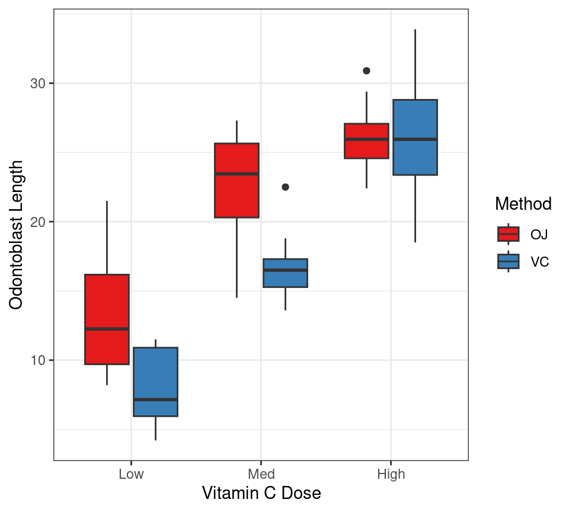

```r
## First change the original column
pigs$dose <- factor(
  pigs$dose, levels = c("Low", "Med", "High")
)
## Then make the plot
ggplot(
  pigs, aes(x = dose, y = len, fill = supp)
) +
  geom_boxplot() +
  scale_fill_brewer(palette = "Set1") +
  labs(
    x = "Vitamin C Dose",
    y = "Odontoblast Length",
    fill = "Method"
  ) +
  theme_bw()
```

## Factors

- All plotting functions automatically coerce strings to factors
- Performing manually gives far greater control
- Also useful for setting reference levels during statistical analysis